# R Notebook

```r
library(tidyverse)
library(infer)
sleep <- data(msleep)

sleep <- msleep
```

Q1:

alpha = 0.05 h0 = mean_sleep_total - 7 = 0 hA = mean_sleep_total - 7 != 0

```r
sleep_stat <- sleep %>%
  summarise(mean = mean(sleep_total))
```

```r
null_distribution <- sleep %>%
  specify(response = sleep_total) %>%
  hypothesise(null = "point", mu = 7) %>%
  generate(reps = 1000, type = "bootstrap") %>%
  calculate(stat = "mean")
```

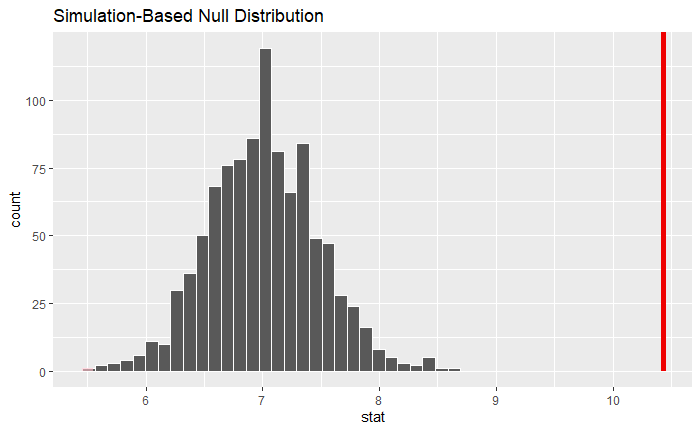

```r
null_distribution %>%
  visualise(bins = 30) +
  shade_p_value(obs_stat = sleep_stat$mean, direction = "both")
```

```r
null_distribution %>%
  get_p_value(obs_stat = sleep_stat$mean, direction = "both")
```

| p_value |
| --- |
| 0 |

p-value close to 0 means we can reject our null hypothesis and confirm that the mean sleep time of animals in the dataset differs statistically significantly from the 7 hours of jabberwockies

Q2:

alpha = 0.05 h0 = mean_omni_sleep - mean_herb_sleep = 0 hA = mean_omni_sleep - mean_herb_sleep > 0

Independent samples so combine the rows

```r
omni_and_herbi <- sleep %>%
  filter(vore == "omni" | vore == "herbi") %>%
  select(c(sleep_total, vore))
```

Create null distribution, swap labels

```r
null_distribution_vore <- omni_and_herbi %>%
  specify(sleep_total ~ vore) %>%
  hypothesise(null = "independence") %>%
  generate(reps = 1000, type = "permute") %>%
  calculate(stat = "diff in means", order = c("omni", "herbi"))
```

Observed stat using infer

```r
observed_stat_vore <- omni_and_herbi %>%
  specify(sleep_total~vore) %>%
  calculate(stat = "diff in means", order = c("omni", "herbi"))
```

Visualise and calculate p value

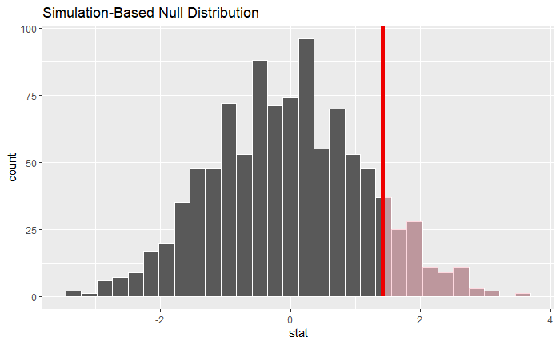

```r
null_distribution_vore %>%
  visualise(bins = 30) +
  shade_p_value(obs_stat = observed_stat_vore, direction = "greater")
```

```r
null_distribution_vore %>%
  get_p_value(obs_stat = observed_stat_vore, direction = "greater")
```

| p_value |
| --- |
| 0.11 |

p-value of 0.106 > 0.05 alpha value so we fail to reject the null hypothesis. Can’t say that the mean sleep time of omnivores is statistically, significantly greater than herbivores.

Q3:

Perform an appropriate statistical test to determine whether the proportion of domesticated animal types in the population of animal types is greater than 5%.

alpha = 0.05 h0 = prop_domestic - 0.05 = 0 hA = prop_domestic - 0.05 > 0

```r
dom <- sleep %>%
  filter(!is.na(conservation)) %>%
  mutate(is_domesticated = if_else(conservation == "domesticated", TRUE, FALSE))
```

```r
null_distribution_dom <- dom %>%
  specify(response = is_domesticated, success = "TRUE") %>%
  hypothesise(null = "point", p = 0.05) %>%
  generate(reps = 5000, type = "draw") %>%
  calculate(stat = "prop")
```

null distribution looks strange

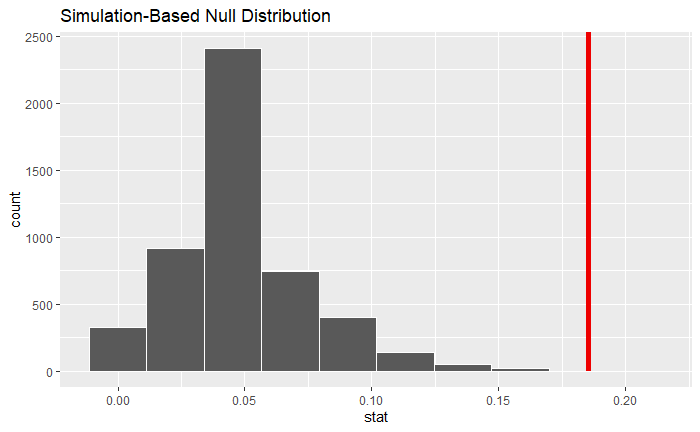

```r
null_distribution_dom %>%
  visualise(bins = 10) +
  shade_p_value(obs_stat = observed_stat_dom, direction = "greater")
```

```r
null_distribution_dom %>%
  get_p_value(obs_stat = observed_stat_dom, direction = "greater")
```

| p_value |
| --- |
| 6e-04 |

p-value 6e-04 much smaller than 0.05 alpha so we can reject the null hypothesis and state that the proportion of domesticated animals is greater than 5%

> 1.2

Q1:

One sample proportion test h0: prop_known - 0.4 = 0

The proportion of people who know the coffee shop is 40%

hA: prop_known - 0.4 > 0

The proportion of people who know the coffee shop is greater than 40%

alpha = 0.05

Draw method

Q2:

Two sample proportion test

h0: B_click_prop - A_click_prop = 0

Users aren’t more likely to click the banner if it’s positioned at the top of the page

hA: B_click_prop - A_click_prop > 0

Users are more likely to click the banner if it’s positioned at the top of the page

alpha = 0.05

Permute method

Q3:

One sample mean test

h0: mean_width = 145

The mean width is 145mm

hA: mean_width != 145

The mean width is significantly different from 145mm

alpha = 0.01

bootstrap method

> 1.3

Q1:

p-value 0.07 > 0.05 alpha so we fail to reject the null hypothesis. Number of people who know the coffee shop is likely 40% or less.

Q2:

```r
transactions <- read_csv("data/online_retail_subset.csv")
```

```r
num_a <- transactions %>%
  filter(StockCode == 22469) %>%
  nrow()

support_a <- num_a / nrow(transactions)
```

```r
library(arulesViz)
```

```r
transactions_reformat <- transactions %>%
  select(InvoiceNo, Description) %>%
  na.omit()

write_csv(transactions_reformat, "transactions_reformat.csv")

apriori_format <- read.transactions("transactions_reformat.csv", format = "single", sep = ",", header = TRUE, cols = c("InvoiceNo", "Description"))
```

```r
rules
```

```
set of 0 rules
```